# Project Proposal by Yue Ma

Yue Ma

# Introduction to problem/question

Compare the performance of different time series classification models

# Problem / Question

Time series data is of tremendous importance in the field of environmental sustainability. Exploring this kind of data helps us understand the pattern of ecosystems, which allows us to detect the abnormal changes in time and help the relative department to make decisions. In this study, I will compare the performances of two state-of-the-art time series classification (TSC) models, fully convectional neural network (FCN) and deep Residual Network (ResNet).

# Inspiring Examples

## Example 1

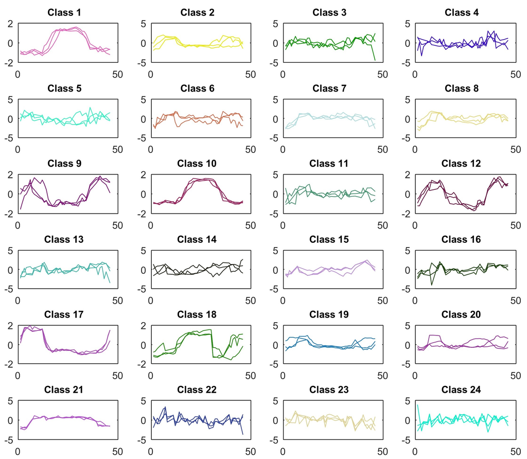

As shown in the figure, different types of objects have different time series data features, and this kind of pattern can help us to distinguish them. Besides, by analyzing time series data, we can detect the abnormal change within one class and make according response to it.

## Example 2

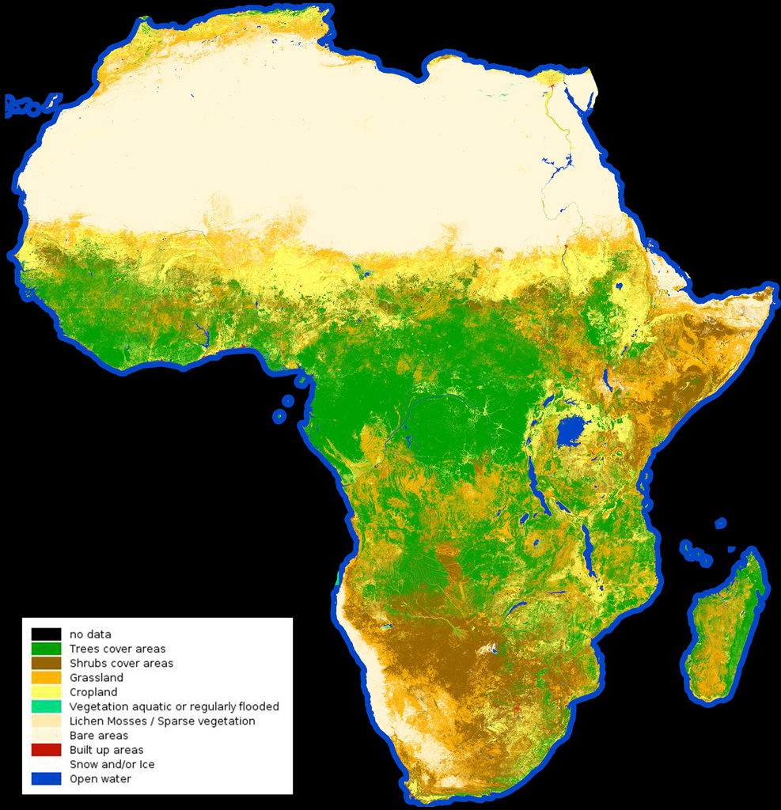

## Example 3

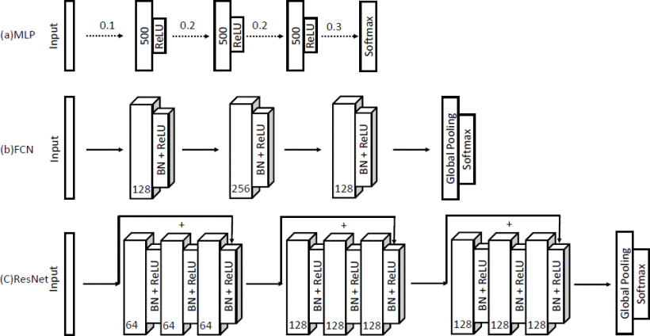

# Proposed data sources

[land cover classification dataset](https://wapor.apps.fao.org/catalog/WaPOR_2/1/L1_LCC_A): In this study I assume that the land cover type does not change within one year.

[NDVI data](https://lpdaac.usgs.gov/products/mod13q1v006/): The time period of the NDVI data is from 2009 to 2016.

[CHELSA dataset](https://chelsa-climate.org/downloads/): monthly precipitation data, temperature data (mean) from 2009 to 2016.

[soil data](https://github.com/AdamWilsonLab/emma_envdata/releases/download/processed_static/soil_Total_N_.tif): In this study I assume that the soil type data of the study area does not change from 2009 to 2016.

[topodiversity data](https://github.com/AdamWilsonLab/emma_envdata/releases/download/processed_static/alos_topodiversity.tif): topographic diversity stands for the variation of landforms present in an area. In this study I also assume that the topographic diversity of this study area does not change during this time period.

The data used in this study is in two categories: static and dynamic. The precipitation data and temperature data are considered as dynamic data while the soil data and topodiversity data are considered as static data. (Another potential research question for this study is whether the static and dynamic data have same importance in this classification task)

# Proposed methods

This study can be divided into four parts:

[figure not shown]

# Expected results

After the training part, I will get two well-trained models. Then I will use the test dataset to evaluate their performance and get the results. The comparison result will be displayed in a table.